# matplotlib.axis.Axis.set_major_formatter

**Axis.set_major_formatter(*formatter*)[[source]](https://github.com/matplotlib/matplotlib/blob/v3.7.1/lib/matplotlib/axis.py#L1792-L1816)**

Set the formatter of the major ticker.

In addition to a `Formatter` instance, this also accepts a `str` or function.

For a `str` a `StrMethodFormatter` is used. The field used for the value must be labeled `'x'` and the field used for the position must be labeled `'pos'`. See the `StrMethodFormatter` documentation for more information.

For a function, a `FuncFormatter` is used. The function must take two inputs (a tick value `x` and a position `pos`), and return a string containing the corresponding tick label. See the `FuncFormatter` documentation for more information.

**Parameters:**

**formatter**`Formatter`, `str`, or function**

## Examples using `matplotlib.axis.Axis.set_major_formatter`

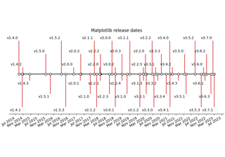

[Creating a timeline with lines, dates, and text](https://matplotlib.org/stable/gallery/lines_bars_and_markers/timeline.html#sphx-glr-gallery-lines-bars-and-markers-timeline-py)

Creating a timeline with lines, dates, and text

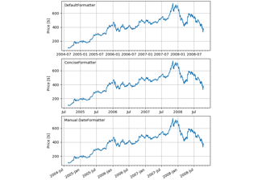

[Date tick labels](https://matplotlib.org/stable/gallery/text_labels_and_annotations/date.html#sphx-glr-gallery-text-labels-and-annotations-date-py)

Date tick labels

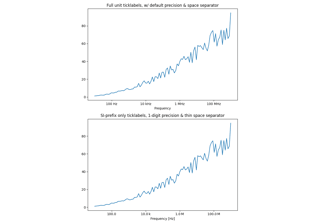

[Labeling ticks using engineering notation](https://matplotlib.org/stable/gallery/text_labels_and_annotations/engineering_formatter.html#sphx-glr-gallery-text-labels-and-annotations-engineering-formatter-py)

Labeling ticks using engineering notation

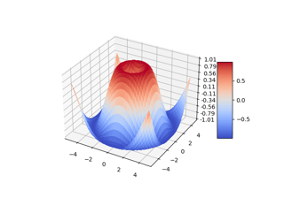

[3D surface (colormap)](https://matplotlib.org/stable/gallery/mplot3d/surface3d.html#sphx-glr-gallery-mplot3d-surface3d-py)

3D surface (colormap)

[figure not shown]

[SkewT-logP diagram: using transforms and custom projections](https://matplotlib.org/stable/gallery/specialty_plots/skewt.html#sphx-glr-gallery-specialty-plots-skewt-py)

SkewT-logP diagram: using transforms and custom projections

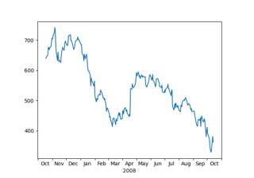

[Centering labels between ticks](https://matplotlib.org/stable/gallery/ticks/centered_ticklabels.html#sphx-glr-gallery-ticks-centered-ticklabels-py)

Centering labels between ticks

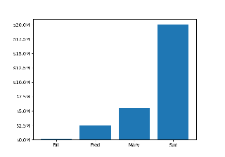

[Custom Ticker](https://matplotlib.org/stable/gallery/ticks/custom_ticker1.html#sphx-glr-gallery-ticks-custom-ticker1-py)

Custom Ticker

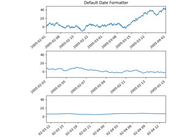

[Formatting date ticks using ConciseDateFormatter](https://matplotlib.org/stable/gallery/ticks/date_concise_formatter.html#sphx-glr-gallery-ticks-date-concise-formatter-py)

Formatting date ticks using ConciseDateFormatter

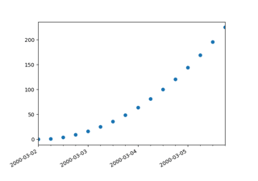

[Date Demo Convert](https://matplotlib.org/stable/gallery/ticks/date_demo_convert.html#sphx-glr-gallery-ticks-date-demo-convert-py)

Date Demo Convert

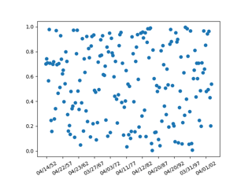

[Placing date ticks using recurrence rules](https://matplotlib.org/stable/gallery/ticks/date_demo_rrule.html#sphx-glr-gallery-ticks-date-demo-rrule-py)

Placing date ticks using recurrence rules

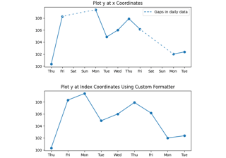

[Custom tick formatter for time series](https://matplotlib.org/stable/gallery/ticks/date_index_formatter.html#sphx-glr-gallery-ticks-date-index-formatter-py)

Custom tick formatter for time series

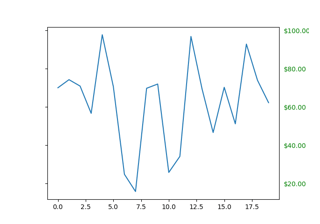

[Dollar ticks](https://matplotlib.org/stable/gallery/ticks/dollar_ticks.html#sphx-glr-gallery-ticks-dollar-ticks-py)

Dollar ticks

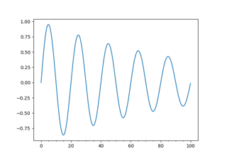

[Major and minor ticks](https://matplotlib.org/stable/gallery/ticks/major_minor_demo.html#sphx-glr-gallery-ticks-major-minor-demo-py)

Major and minor ticks

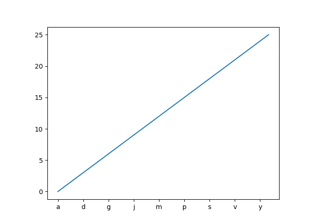

[Setting tick labels from a list of values](https://matplotlib.org/stable/gallery/ticks/tick_labels_from_values.html#sphx-glr-gallery-ticks-tick-labels-from-values-py)

Setting tick labels from a list of values

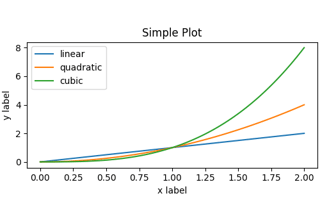

[Quick start guide](https://matplotlib.org/stable/tutorials/introductory/quick_start.html#sphx-glr-tutorials-introductory-quick-start-py)

Quick start guide

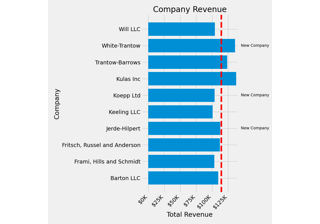

[The Lifecycle of a Plot](https://matplotlib.org/stable/tutorials/introductory/lifecycle.html#sphx-glr-tutorials-introductory-lifecycle-py)

The Lifecycle of a Plot

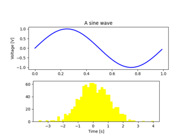

[Artist tutorial](https://matplotlib.org/stable/tutorials/intermediate/artists.html#sphx-glr-tutorials-intermediate-artists-py)

Artist tutorial

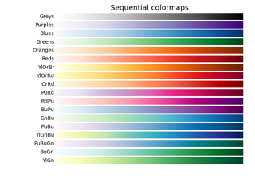

[Choosing Colormaps in Matplotlib](https://matplotlib.org/stable/tutorials/colors/colormaps.html#sphx-glr-tutorials-colors-colormaps-py)

Choosing Colormaps in Matplotlib

[Text in Matplotlib Plots](https://matplotlib.org/stable/tutorials/text/text_intro.html#sphx-glr-tutorials-text-text-intro-py)

Text in Matplotlib Plots

© 2012–2023 Matplotlib Development Team. All rights reserved.  
Licensed under the Matplotlib License Agreement.  
https://matplotlib.org/stable/api/_as_gen/matplotlib.axis.Axis.set_major_formatter.html